# Lesson 3

### What to Do First?

Notes: Load the data ***

### Pseudo-Facebook User Data

Notes:

```r
getwd()
```

```
## [1] "C:/learning/Udacity/Data Analysis with R/L3_Explore_One_Variable"
```

```r
setwd("C:/learning/Udacity/Data Analysis with R/L3_Explore_One_Variable")
list.files()
```

```
## [1] "lesson3_student.rmd"   "lesson3_student_files" "pseudo_facebook.tsv"
```

```r
pf <- read.csv("pseudo_facebook.tsv", sep = '\t')
names(pf)
```

```
##  [1] "userid"                "age"
##  [3] "dob_day"               "dob_year"
##  [5] "dob_month"             "gender"
##  [7] "tenure"                "friend_count"
##  [9] "friendships_initiated" "likes"
## [11] "likes_received"        "mobile_likes"
## [13] "mobile_likes_received" "www_likes"
## [15] "www_likes_received"
```

### Histogram of Users’ Birthdays

Notes:

```r
library(ggplot2)
names(pf)
```

```
##  [1] "userid"                "age"
##  [3] "dob_day"               "dob_year"
##  [5] "dob_month"             "gender"
##  [7] "tenure"                "friend_count"
##  [9] "friendships_initiated" "likes"
## [11] "likes_received"        "mobile_likes"
## [13] "mobile_likes_received" "www_likes"
## [15] "www_likes_received"
```

```r
library(ggthemes)
```

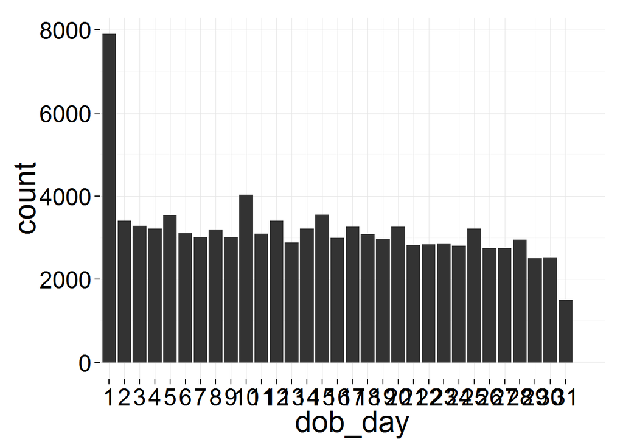

```r
theme_set(theme_minimal(24))
qplot(x = dob_day, data=pf)+scale_x_discrete(breaks=1:31)
```

### Moira’s Investigation

Notes: - How a person who posted a facebook post, thinks how many people actually saw the post vs how many actually see the post ***

### Estimating Your Audience Size

Notes: - 10 people might see my post - 50% might see the post ***

#### Think about a time when you posted a specific message or shared a photo on Facebook. What was it?

Response: few liks #### How many of your friends do you think saw that post? Response: 10 #### Think about what percent of your friends on Facebook see any posts or comments that you make in a month. What percent do you think that is? Response: 5% ***

### Perceived Audience Size

Notes: 10 *** ### Faceting Notes:

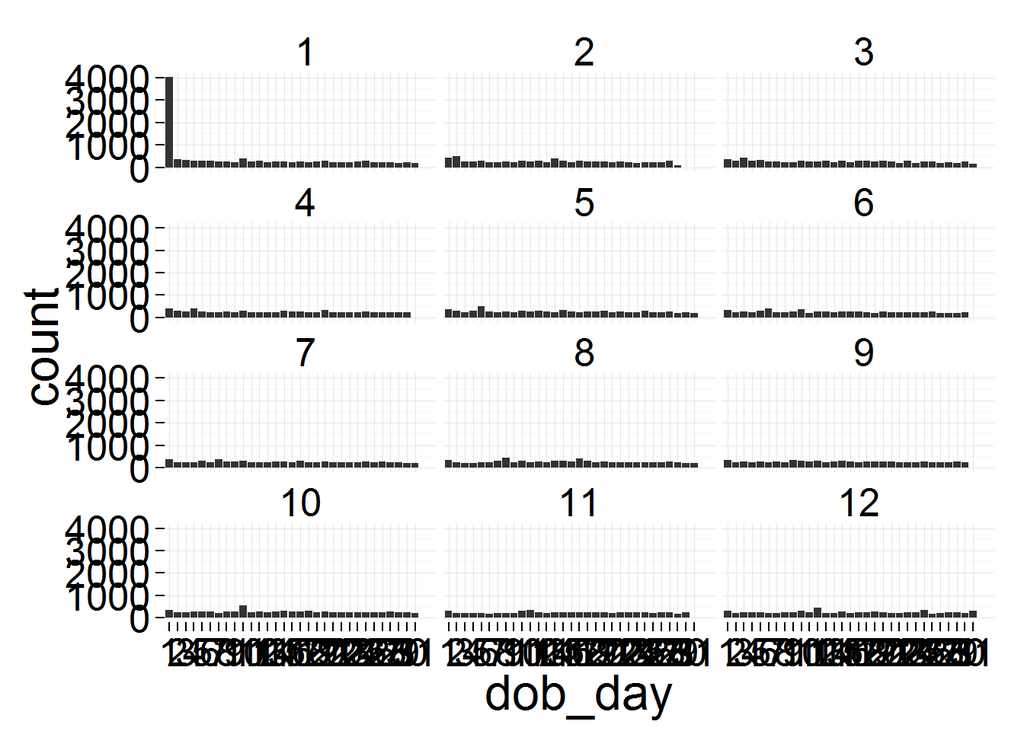

```r
qplot(x = dob_day, data=pf)+scale_x_discrete(breaks=1:31)+facet_wrap(~dob_month, ncol=3)
```

#### Letâs take another look at our plot. What stands out to you here?

Response: - 1st day of January has high number of dob_day ***

### Be Skeptical - Outliers and Anomalies

Notes: - Jan 1st could be because facebook uses default as jan 1st. ***

### Moira’s Outlier

Notes: - Most people guessed smaller number, 1 personal guessd million people #### Which case do you think applies to Moiraâs outlier? Response: - bad data abour an extreme case ***

### Friend Count

Notes:

#### What code would you enter to create a histogram of friend counts?

```r
names(pf)
```

```
##  [1] "userid"                "age"
##  [3] "dob_day"               "dob_year"
##  [5] "dob_month"             "gender"
##  [7] "tenure"                "friend_count"
##  [9] "friendships_initiated" "likes"
## [11] "likes_received"        "mobile_likes"
## [13] "mobile_likes_received" "www_likes"
## [15] "www_likes_received"
```

```
## stat_bin: binwidth defaulted to range/30. Use 'binwidth = x' to adjust this.
```

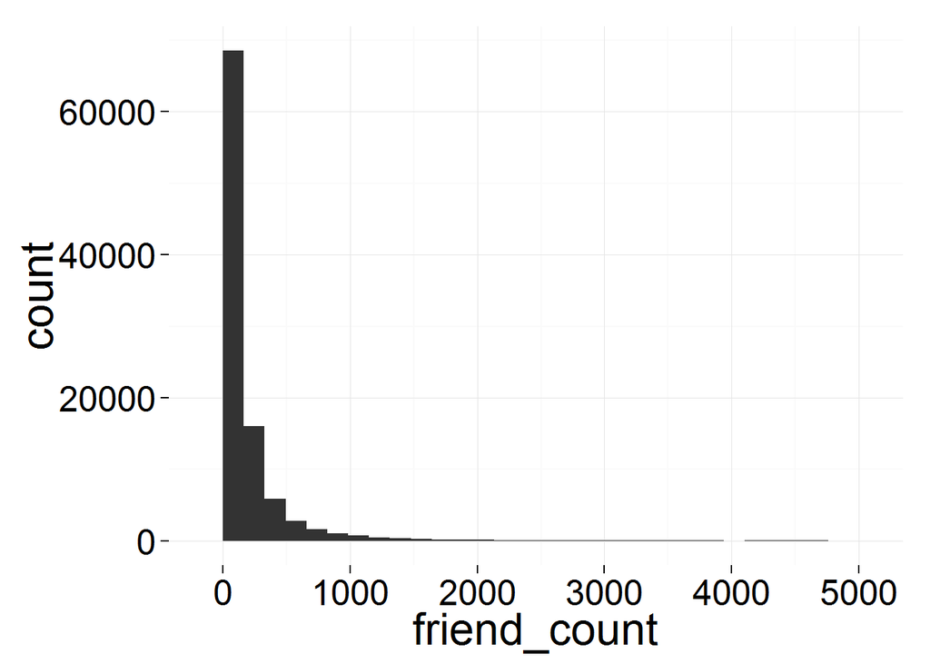

```r
qplot(x = friend_count, data= pf)
```

#### How is this plot similar to Moira’s first plot?

Response: - lot of users have 0 as friend count and we are uable to see the users who have more friends ***

### Limiting the Axes

Notes:

```
## stat_bin: binwidth defaulted to range/30. Use 'binwidth = x' to adjust this.
```

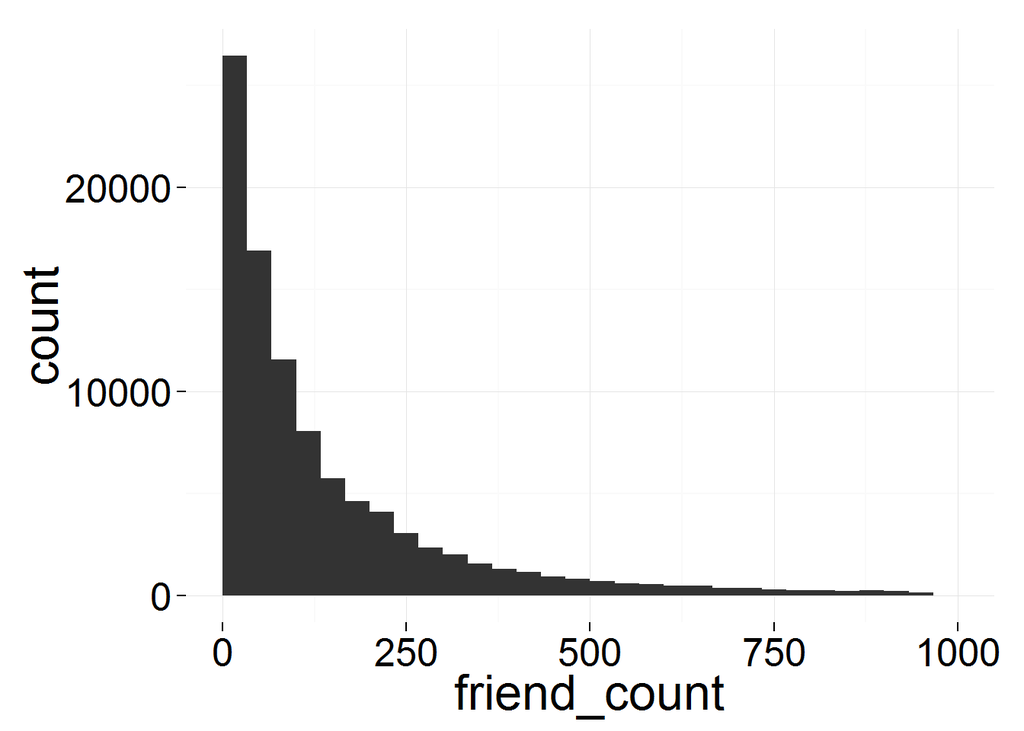

```r
qplot(x = friend_count, data= pf, xlim=c(0,1000))
```

```
## stat_bin: binwidth defaulted to range/30. Use 'binwidth = x' to adjust this.
```

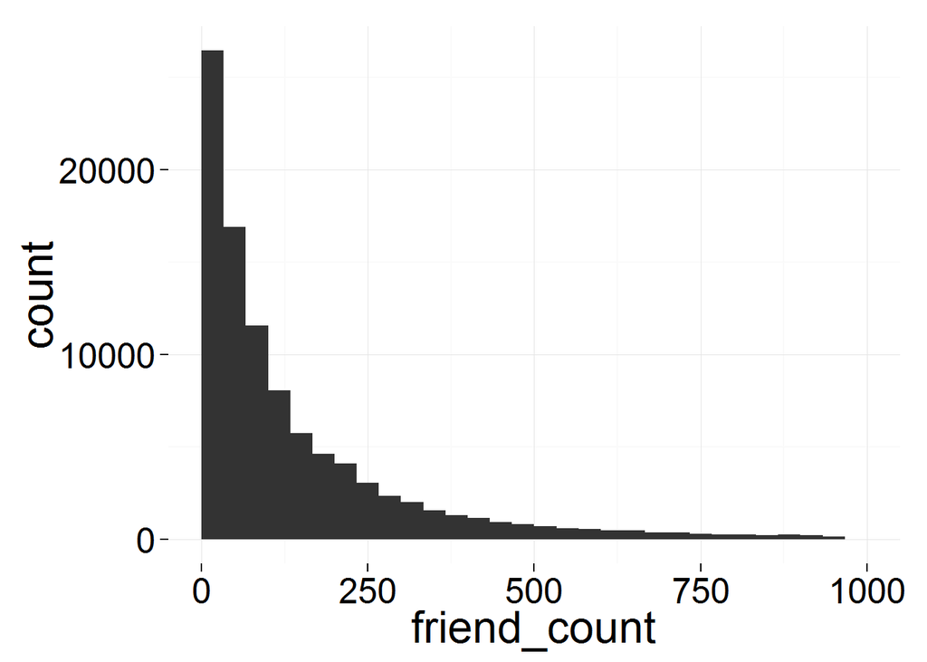

```r
qplot(x = friend_count, data= pf)+scale_x_continuous(limits=c(0,1000))
```

### Exploring with Bin Width

Notes: using bin width helps to see the data clearly ***

### Adjusting the Bin Width

Notes: Adjusting bin width moira was able to read the data in details. ### Faceting Friend Count

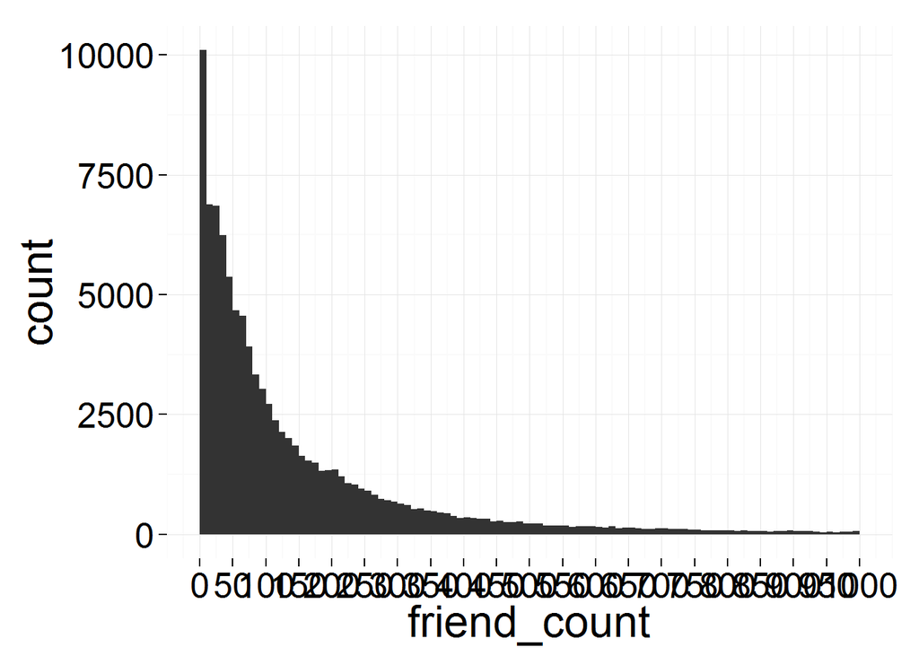

```r
# What code would you add to create a facet the histogram by gender?
# Add it to the code below.
qplot(x = friend_count, data = pf, binwidth = 10) +
  scale_x_continuous(limits = c(0, 1000),
                     breaks = seq(0, 1000, 50))
```

### Omitting NA Values

Notes:

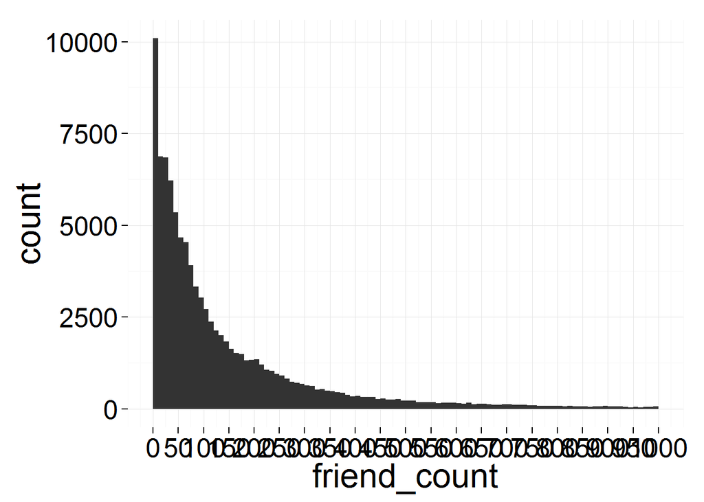

```r
qplot(x = friend_count, data = na.omit(pf), binwidth = 10) +
  scale_x_continuous(limits = c(0, 1000),
                     breaks = seq(0, 1000, 50))
```

### Statistics ‘by’ Gender

Notes:

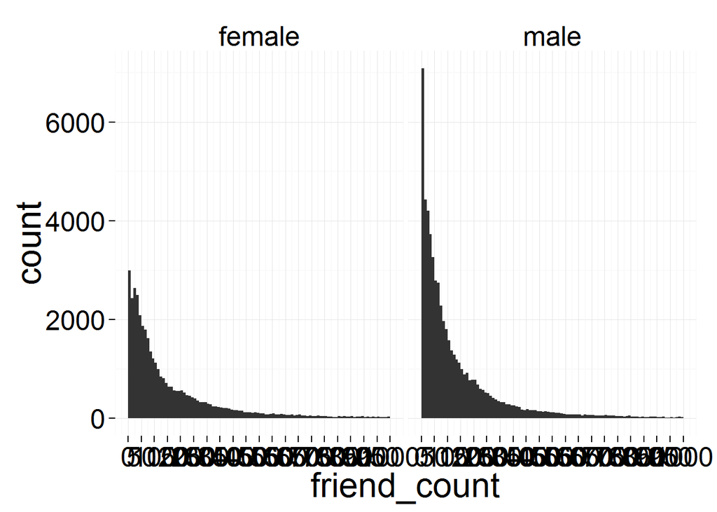

```r
qplot(x = friend_count, data = subset(pf, !is.na(gender)), binwidth = 10) +
  scale_x_continuous(limits = c(0, 1000),
                     breaks = seq(0, 1000, 50))+facet_wrap(~gender)
```

#### Who on average has more friends: men or women?

Response: table(pf$gender) by(pf$friend_count, pf$gender, summary) women

#### What’s the difference between the median friend count for women and men?

Response: 22 #### Why would the median be a better measure than the mean? Response: Because number of male and female is different if they were same then mean would have probably made more sense. Mean is more robust statistic ***

### Tenure

Notes:

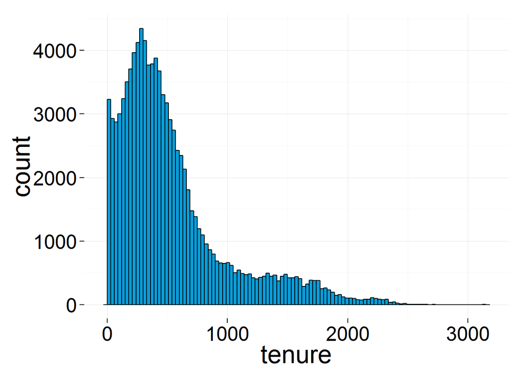

```r
qplot(x=tenure, data=pf, binwidth=30, color=I('black'), fill=I('#099DD9'))
```

#### How would you create a histogram of tenure by year?

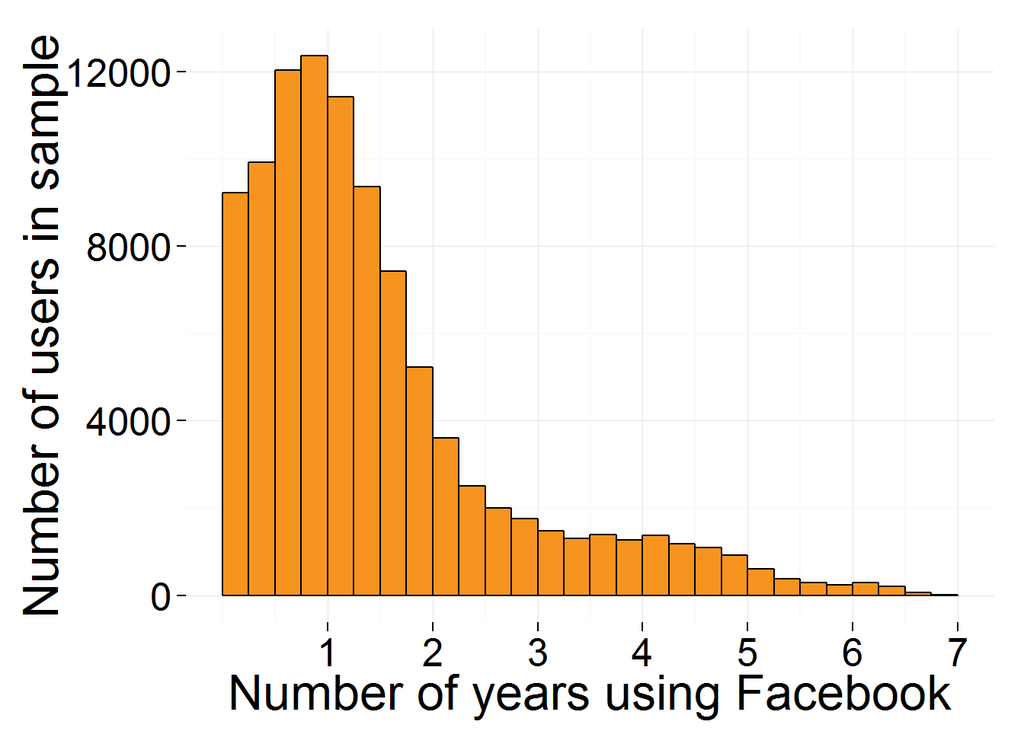

```r
qplot(x=tenure/365, data=pf, binwidth=0.25, color=I('black'), xlab='Number of years using Facebook', ylab='Number of users in sample', fill=I('#F79420'))+scale_x_continuous(breaks=seq(1,7,1), limits=c(0,7))
```

### Labeling Plots

Notes:

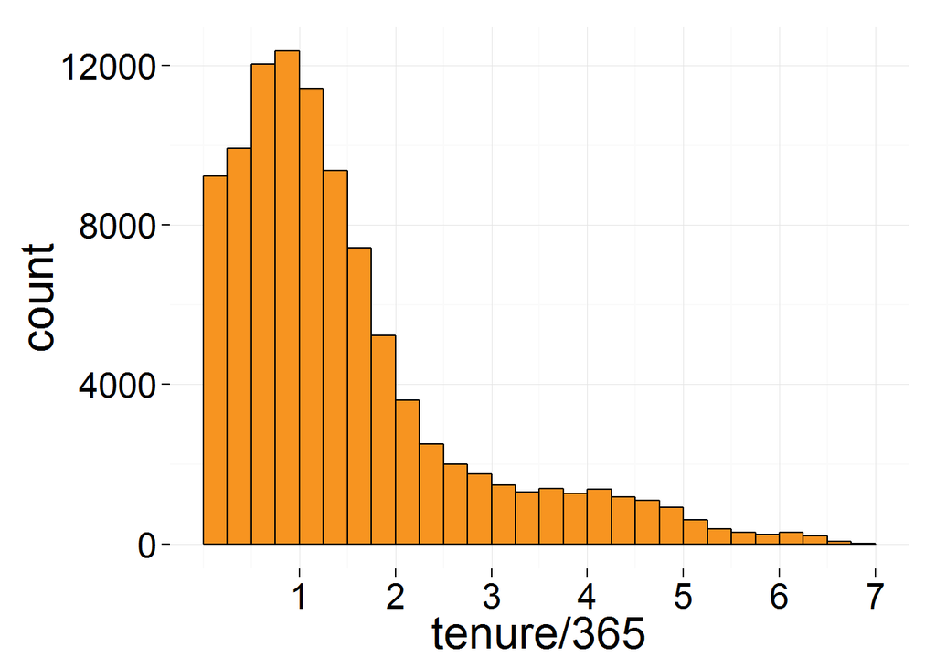

```r
qplot(x=tenure/365, data=pf, binwidth=0.25, color=I('black'), fill=I('#F79420'))+scale_x_continuous(breaks=seq(1,7,1), limits=c(0,7))
```

### User Ages

Notes:

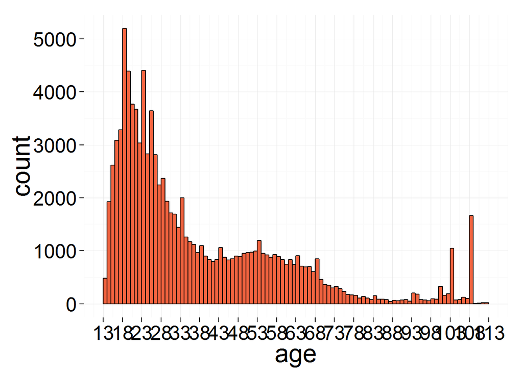

```r
qplot(x=age, data=pf,binwidth=1, color=I('black'), fill=I('#F56440'))+scale_x_continuous(breaks=seq(13,113,5), limits=c(13,113))
```

#### What do you notice?

Response: Most of the users in the age from 15-35. ***

### The Spread of Memes

Notes: histogram is used see the spread of meme ***

### Lada’s Money Bag Meme

Notes: using histogram ***

### Transforming Data

Notes: - apply log or sqrt to tranform the data ***

### Add a Scaling Layer

Notes:

```r
library("gridExtra")
```

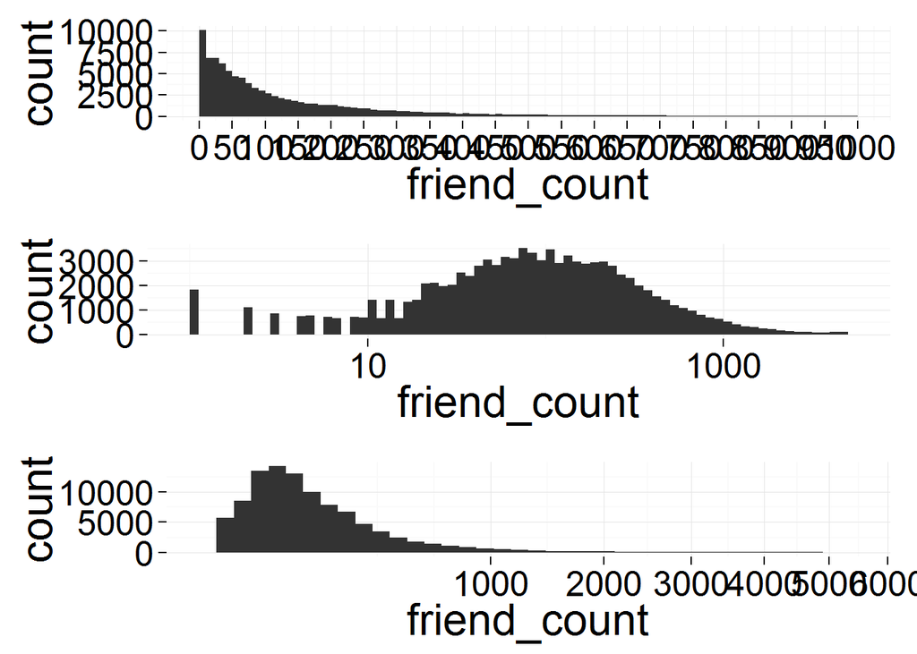

```r
p1 = qplot(x = friend_count, data = na.omit(pf), binwidth = 10) +
  scale_x_continuous(limits = c(0, 1000),
                     breaks = seq(0, 1000, 50))

p2 = qplot(x = friend_count, data = na.omit(pf), binwidth =0.05) +
  scale_x_log10()

p3 = qplot(x = friend_count, data = na.omit(pf), binwidth =2) +
  scale_x_sqrt()

grid.arrange(p1, p2, p3)
```

### Frequency Polygons

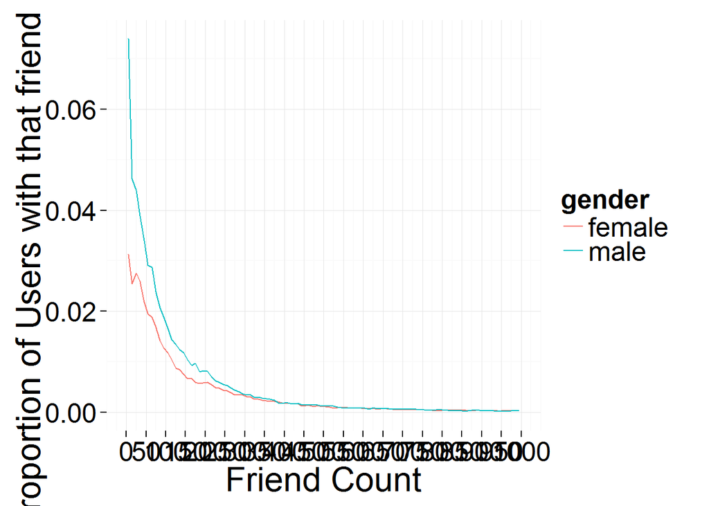

```r
qplot(x=friend_count,y=..count../sum(..count..), data = subset(pf, !is.na(gender)), xlab='Friend Count', ylab='Proportion of Users with that friend count',binwidth=10, geom='freqpoly', color=gender)+scale_x_continuous(lim=c(0,1000), breaks=seq(0,1000,50))
```

### Likes on the Web

Notes:

```r
by(pf$www_likes, pf$gender, sum)
```

```
## pf$gender: female
## [1] 3507665
## --------------------------------------------------------
## pf$gender: male
## [1] 1430175
```

```
## stat_bin: binwidth defaulted to range/30. Use 'binwidth = x' to adjust this.
```

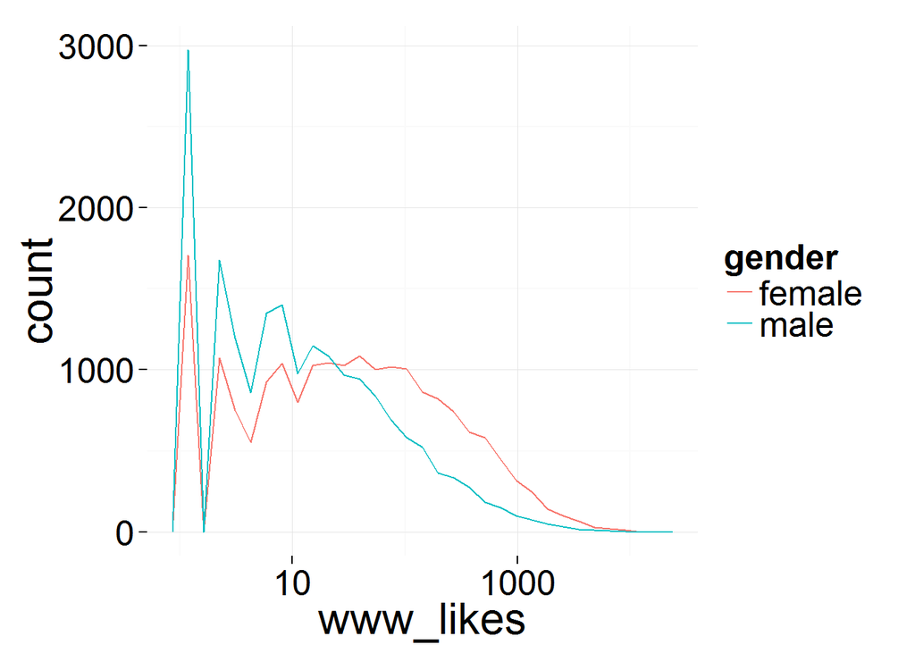

```r
qplot(x=www_likes, data = subset(pf, !is.na(gender)), geom='freqpoly', color=gender)+scale_x_continuous()+scale_x_log10()
```

### Box Plots

Notes:

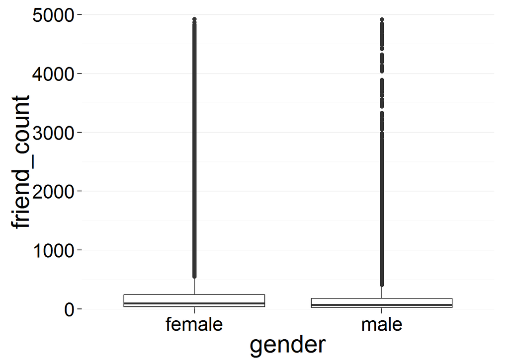

```r
qplot(x=gender, y=friend_count,
      data = subset(pf, !is.na(gender)),
      geom='boxplot')+ coord_cartesian(ylim=c(0,5000))
```

#### Adjust the code to focus on users who have friend counts between 0 and 1000.

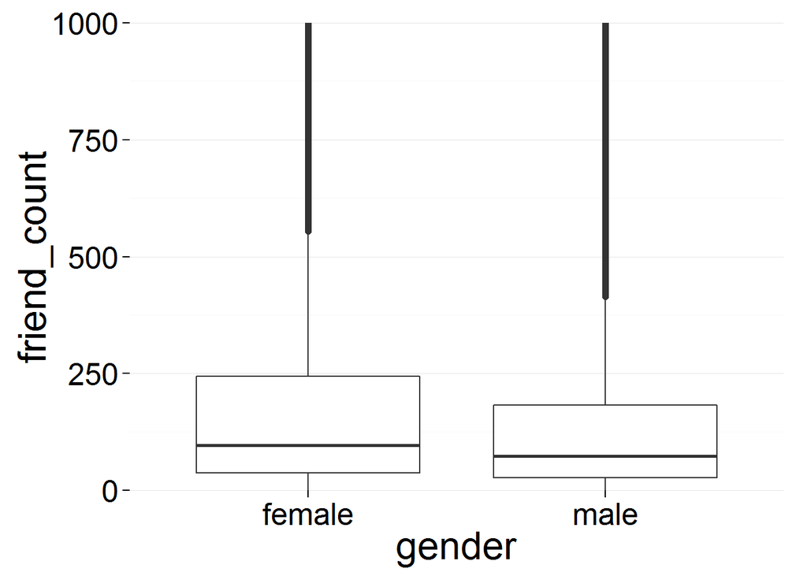

```r
qplot(x=gender, y=friend_count,
      data = subset(pf, !is.na(gender)),
      geom='boxplot')+ coord_cartesian(ylim=c(0,1000))
```

### Box Plots, Quartiles, and Friendships

Notes:

```r
names(pf)
```

```
##  [1] "userid"                "age"
##  [3] "dob_day"               "dob_year"
##  [5] "dob_month"             "gender"
##  [7] "tenure"                "friend_count"
##  [9] "friendships_initiated" "likes"
## [11] "likes_received"        "mobile_likes"
## [13] "mobile_likes_received" "www_likes"
## [15] "www_likes_received"
```

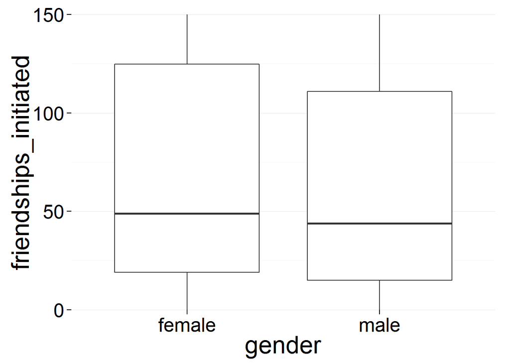

```r
qplot(x=gender, y=friendships_initiated,
      data = subset(pf, !is.na(gender)),
      geom='boxplot')+ coord_cartesian(ylim=c(0,150))
```

```r
by(pf$friendships_initiated, pf$gender, summary)
```

```
## pf$gender: female
##    Min. 1st Qu.  Median    Mean 3rd Qu.    Max.
##     0.0    19.0    49.0   113.9   124.8  3654.0
## --------------------------------------------------------
## pf$gender: male
##    Min. 1st Qu.  Median    Mean 3rd Qu.    Max.
##     0.0    15.0    44.0   103.1   111.0  4144.0
```

#### On average, who initiated more friendships in our sample: men or women?

Response: Women #### Write about some ways that you can verify your answer. Response:

```r
names(pf)
```

```
##  [1] "userid"                "age"
##  [3] "dob_day"               "dob_year"
##  [5] "dob_month"             "gender"
##  [7] "tenure"                "friend_count"
##  [9] "friendships_initiated" "likes"
## [11] "likes_received"        "mobile_likes"
## [13] "mobile_likes_received" "www_likes"
## [15] "www_likes_received"
```

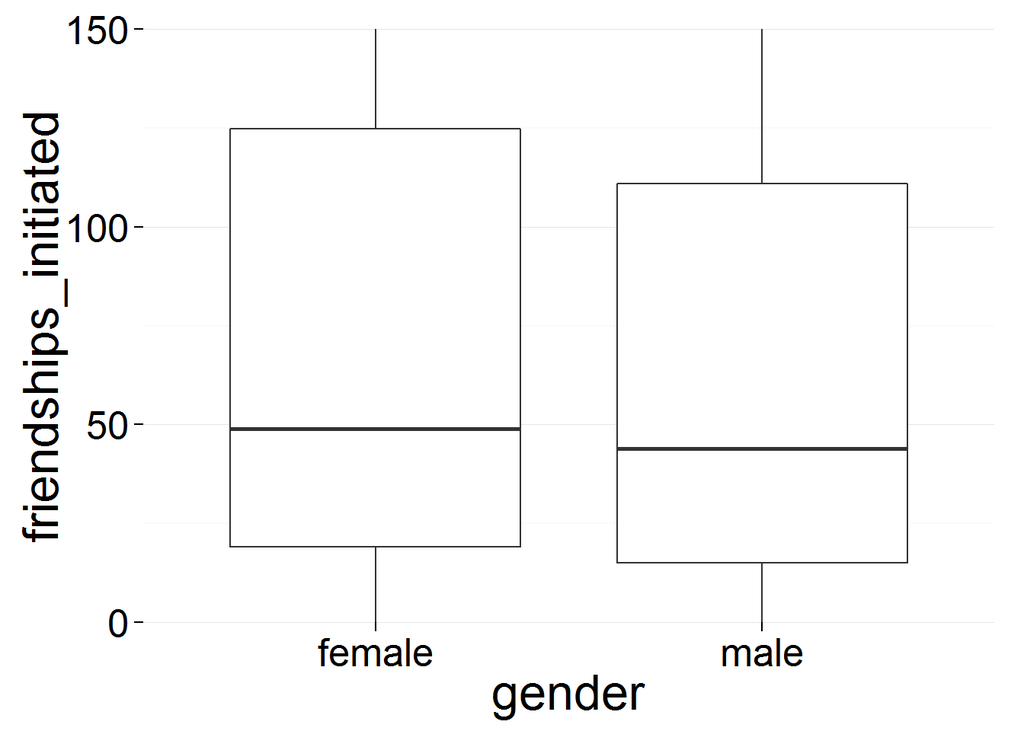

```r
qplot(x=gender, y=friendships_initiated,
      data = subset(pf, !is.na(gender)),
      geom='boxplot')+ coord_cartesian(ylim=c(0,150))
```

```r
by(pf$friendships_initiated, pf$gender, summary)
```

```
## pf$gender: female
##    Min. 1st Qu.  Median    Mean 3rd Qu.    Max.
##     0.0    19.0    49.0   113.9   124.8  3654.0
## --------------------------------------------------------
## pf$gender: male
##    Min. 1st Qu.  Median    Mean 3rd Qu.    Max.
##     0.0    15.0    44.0   103.1   111.0  4144.0
```

Response: - Lookint at median, 1st quartile, 3rd quartile data for both genders, female has more requests initiated. ***

### Getting Logical

Notes:

```r
summary(pf$mobile_likes)
```

```
##    Min. 1st Qu.  Median    Mean 3rd Qu.    Max.
##     0.0     0.0     4.0   106.1    46.0 25110.0
```

```r
summary(pf$mobile_likes > 0)
```

```
##    Mode   FALSE    TRUE    NA's
## logical   35056   63947       0
```

```r
mobile_check_in <- NA
pf$mobile_check_in <- ifelse(pf$mobile_likes > 0, 1, 0)
pf$mobile_check_in <- factor(pf$mobile_check_in)
summary(pf$mobile_check_in)
```

```
##     0     1
## 35056 63947
```

```r
mobile_check_in <- length(pf$mobile_likes > 0)
mobile_check_in
```

```
## [1] 99003
```

```r
length(pf$mobile_likes)
```

```
## [1] 99003
```

```r
percent <- sum(pf$mobile_check_in == 1) / length(pf$mobile_check_in)
percent
```

```
## [1] 0.6459097
```

Response: 64.5 ***

### Analyzing One Variable

Reflection: - Learnt exploring one variable - learnt how to use histogram, freqpoly and boxplot - started following flowingdata.com by Nathan Yau ***

Click **KnitHTML** to see all of your hard work and to have an html page of this lesson, your answers, and your notes!